# 2025-04-16_ARK_approved_access

Jess Vera

Start date: 2025-04-16  
Last updated: 2025-04-16 15:36:25.858588

# Setup

```r
# source rmarkdown_setup.R
source("~/Setup/rmarkdown_setup.R")

# Load libraries silently
suppressPackageStartupMessages({
  library(dplyr)
  library(stringr)
  library(ggplot2)
  library(lubridate)
  library(glue)
})
```

# Main

```r
df <- read.delim("all_accepted_dates.txt", header= FALSE)
colnames(df) <- c("V1", "approved_date")
df <- mutate(df, year = year(mdy(approved_date)),
             month_str = month(mdy(approved_date), label = TRUE, abbr = TRUE),
             month_int = month(mdy(approved_date)))
message(glue("There are {nrow(df)} total access requests that have been approved since the inception of the ARK Portal"))
```

```
## There are 129 total access requests that have been approved since the inception of the ARK Portal
```

```r
df$date <- paste(df$month_str, df$year)
df <- group_by(df, month_int, year, date) %>% tidyr::nest()
df$count <- unlist(purrr::map(df$data, nrow))
df <- arrange(df, year, month_int)
df$date <- forcats::fct_inorder(df$date)
```

```r
df$year <- as.character(df$year)
yrcols <- c("grey85", "grey40", "black")
names(yrcols) <- unique(df$year)

p <- ggplot(df, aes(x = date, y = count, fill = year)) +
       geom_col() + theme_minimal() +
       scale_fill_manual(values = yrcols) +
       theme(text = element_text(size = 8),
             axis.text.x = element_text(angle = 45, vjust = 1, hjust = 1, size = 6),
             title = element_text(size = 10)) +
       ggtitle("ARK Portal Approved Access Requests")

fid <- "ARK Portal Approved Access Requests.png"
png(fid, width = 1100, height = 750, res = 250)
print(p)
invisible(dev.off())
```

# Results

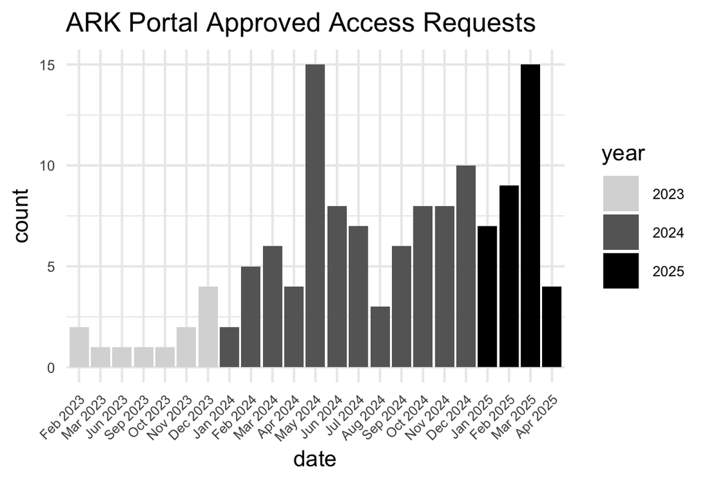

```r
knitr::include_graphics(fid)
```

# Session Details

```r
#Print out session info
R.utils::System$getHostname();
```

```
nodename
```

“w255.local”

R version 4.3.3 (2024-02-29) Platform: aarch64-apple-darwin20 (64-bit) Running under: macOS Sonoma 14.7.3

Matrix products: default BLAS: /Library/Frameworks/R.framework/Versions/4.3-arm64/Resources/lib/libRblas.0.dylib LAPACK: /Library/Frameworks/R.framework/Versions/4.3-arm64/Resources/lib/libRlapack.dylib; LAPACK version 3.11.0

locale: [1] en_US.UTF-8/en_US.UTF-8/en_US.UTF-8/C/en_US.UTF-8/en_US.UTF-8

time zone: America/Chicago tzcode source: internal

attached base packages: [1] stats graphics grDevices utils datasets methods base

other attached packages: [1] glue_1.8.0 lubridate_1.9.4 ggplot2_3.5.1 stringr_1.5.1  
[5] dplyr_1.1.4

loaded via a namespace (and not attached): [1] gtable_0.3.6 jsonlite_1.8.9 compiler_4.3.3 tidyselect_1.2.1 [5] tidyr_1.3.1 jquerylib_0.1.4 png_0.1-8 scales_1.3.0  
[9] yaml_2.3.10 fastmap_1.2.0 R6_2.5.1 labeling_0.4.3  
[13] generics_0.1.3 knitr_1.49 forcats_1.0.0 tibble_3.2.1  
[17] munsell_0.5.1 bslib_0.8.0 pillar_1.10.0 R.utils_2.12.3  
[21] rlang_1.1.4 cachem_1.1.0 stringi_1.8.4 xfun_0.49  
[25] sass_0.4.9 timechange_0.3.0 cli_3.6.3 withr_3.0.2  
[29] magrittr_2.0.3 digest_0.6.37 grid_4.3.3 rstudioapi_0.17.1 [33] lifecycle_1.0.4 R.oo_1.27.0 R.methodsS3_1.8.2 vctrs_0.6.5  
[37] evaluate_1.0.1 farver_2.1.2 colorspace_2.1-1 purrr_1.0.2  
[41] rmarkdown_2.29 httr_1.4.7 tools_4.3.3 pkgconfig_2.0.3  
[45] htmltools_0.5.8.1